# Distribuciones Discretas II

Edimer David Jaramillo

4 de mayo de 2018

# Distribución Geométrica

De gran utilidad cuando el problema de interés es modelar la distribución del número de ensayos necesarios para encontrar el **primer éxito**.

Una variable aleatoria $X$ tiene distribución Geométrica si su función de densidad (f.m.p) es:
$$f(x) = p(1-p)^{x-1};\ x = 1, 2, 3, ...$$

Notación:
$$X \sim Geo(p)$$

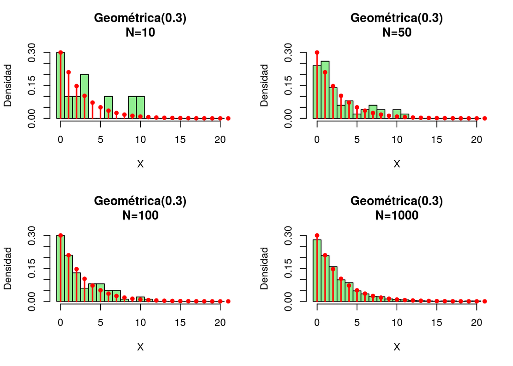

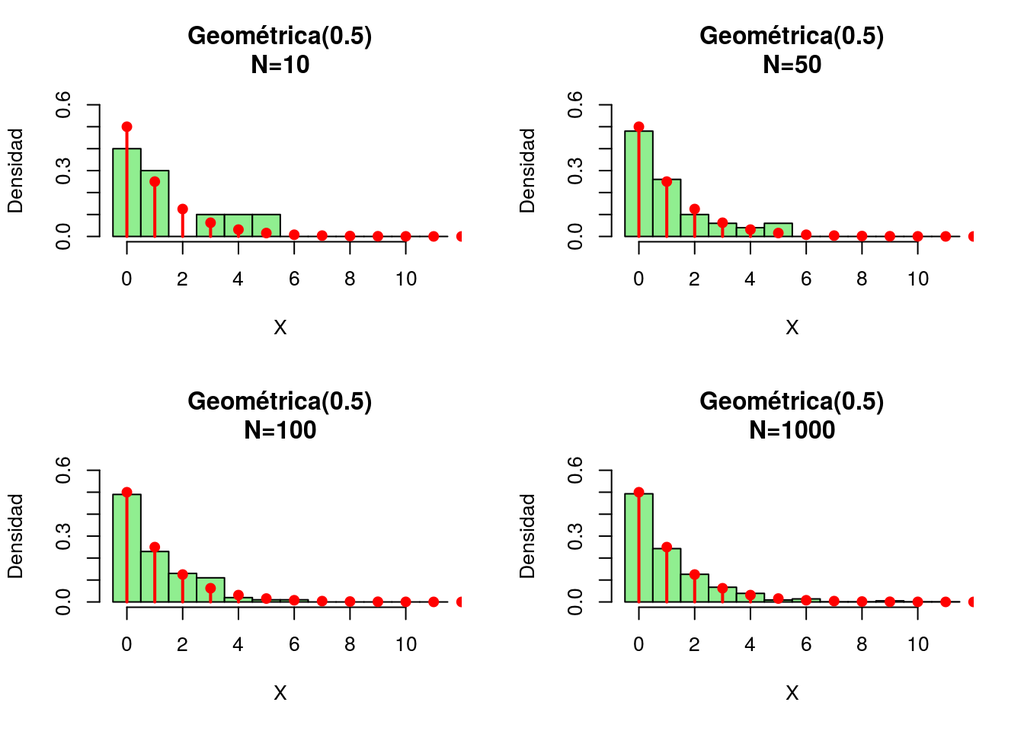

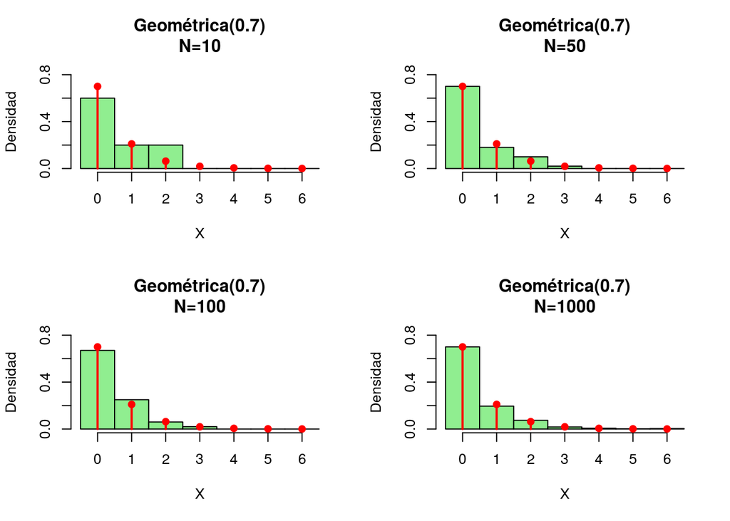

[Código en R de gráficas de distribuciones](https://rpubs.com/cdsantae/Distribuciones)

**Diferencias entre distribuciones Binomial y Geométrica:**

- **Binomial (1):** número fijo de ensayos $n$
- **Geométrica (1):** número aleatorio de ensayos $n$
- **Binomial (2):** número de aleatorio de éxitos $X$
- **Geométrica (2):** número fijo de éxitos $X$ (en este caso, igual a 1)

## Esperanza ($E[X]$) y varianza ($Var[X]$)

- $E[x] = \frac{1}{p}$
- $Var[x]= \frac{1-p}{p^2}$

## Ejemplo

- Suponga que de registros históricos en una fábrica dedicada a producir bombillos, se conoce que la probabilidad de que un bombillo esté dañado es 0.01. Se asume que los bombillos evaluados son independientes. Obtener:
  - La probabilidad de que se necesite analizar exactamente 125 bombillos para encontrar uno defectuoso.
  - La probabilidad de que se necesite analizar máximo 50 bombillos para encontrar uno defectuoso.
  - La esperanza matemática

**Solución:**
$$f(x) = p(1-p)^{x-1} \\
f(125) = 0.01(1-0.01)^{125-1} = 0.0028$$

Funciones importantes:

- `rgeom()`: generar números bajo la distribución Geométrica
- `dgeom()`: función masa de probabilidad
- `pgeom()`: función de distribución acumulada

```r
# P(X = 125)
dgeom(x = 125, prob = 0.01)
```

```
## [1] 0.002847078
```

```r
#P(X <= 50)
sum(dgeom(x = 0:50, prob = 0.01))
```

```
## [1] 0.401044
```

```r
pgeom(q = 50, prob = 0.01)
```

```
## [1] 0.401044
```

```r
1 - pgeom(q = 50, prob = 0.01, lower.tail = FALSE)
```

```
## [1] 0.401044
```

```r
#Esperanza matemática
(espGeom <- 1/0.01)
```

```
## [1] 100
```

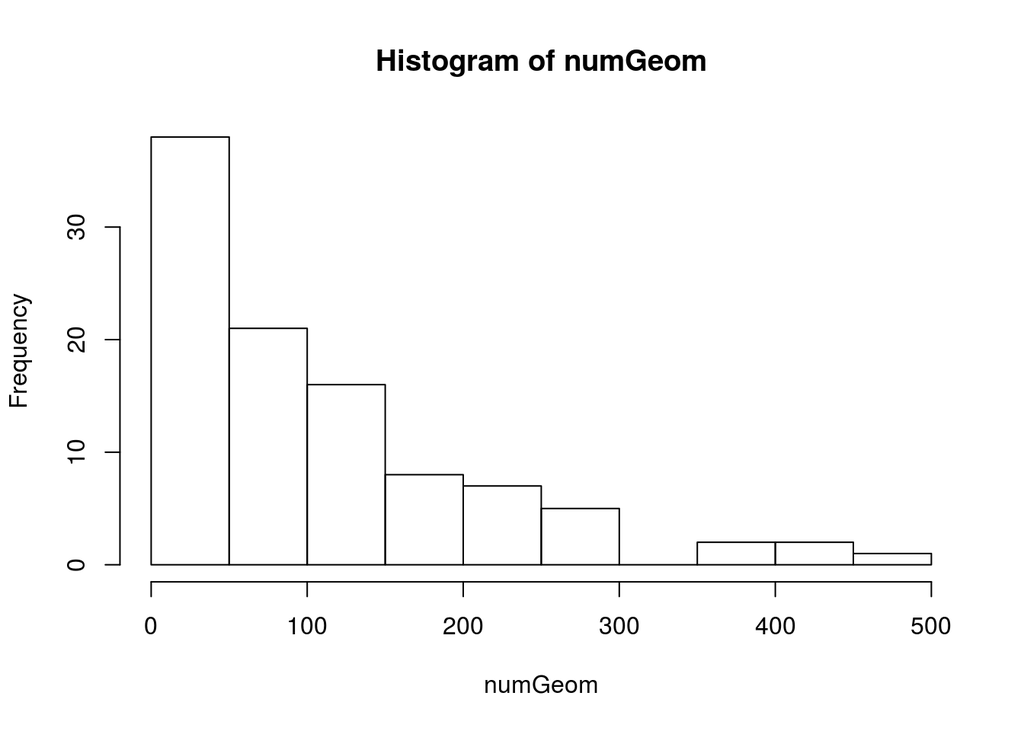

```r
numGeom <- rgeom(n = 100, prob = 0.01)
hist(numGeom)
```